# Working with United States Census Data Using tidycensus

```r
library(tidycensus)
library(tidyverse)
census_api_key("YOUR API KEY GOES HERE")
```

## Inspect variables for Decennial Census

```r
decennial_variables<-load_variables(2010,"sf1")
View(decennial_variables)
```

| name | label | concept |
| --- | --- | --- |
| H001001 | Total | HOUSING UNITS |
| H002001 | Total | URBAN AND RURAL |
| H002002 | Total!!Urban | URBAN AND RURAL |
| H002003 | Total!!Urban!!Inside urbanized areas | URBAN AND RURAL |
| H002004 | Total!!Urban!!Inside urban clusters | URBAN AND RURAL |
| H002005 | Total!!Rural | URBAN AND RURAL |

## Calling and Manipulating Data using tidycensus and dplyr: Basics

### Calling and Viewing Data

Let’s find out the population, by state, in 2010:

```r
state_population_2010<-get_decennial(geography = "state",
                                     variables = "P001001",
                                     geometry=TRUE,
                                     shift_geo = TRUE,
                                     year = 2010)
View(state_population_2010)
```

| GEOID | NAME | variable | value | geometry |
| --- | --- | --- | --- | --- |
| 04 | Arizona | P001001 | 6392017 | MULTIPOLYGON (((-1111066 -8… |
| 05 | Arkansas | P001001 | 2915918 | MULTIPOLYGON (((557903.1 -1… |
| 06 | California | P001001 | 37253956 | MULTIPOLYGON (((-1853480 -9… |
| 08 | Colorado | P001001 | 5029196 | MULTIPOLYGON (((-613452.9 -… |
| 09 | Connecticut | P001001 | 3574097 | MULTIPOLYGON (((2226838 519… |
| 11 | District of Columbia | P001001 | 601723 | MULTIPOLYGON (((1960720 -41… |

We can adjust the geography and year parameters; let’s say we want the population distribution across CO counties in the year 2010:

```r
CO_county_population_2010<-get_decennial(geography = "county",
                                         state="CO",
                                         variables = "P001001",
                                         year = 2010)
View(CO_county_population_2010)
```

| GEOID | NAME | variable | value |
| --- | --- | --- | --- |
| 08023 | Costilla County, Colorado | P001001 | 3524 |
| 08025 | Crowley County, Colorado | P001001 | 5823 |
| 08027 | Custer County, Colorado | P001001 | 4255 |
| 08029 | Delta County, Colorado | P001001 | 30952 |
| 08031 | Denver County, Colorado | P001001 | 600158 |
| 08035 | Douglas County, Colorado | P001001 | 285465 |

### Cleaning and Manipulating Data Using dplyr

```r
CO_county_population_2010<-get_decennial(geography = "county",
                                         state="CO",
                                         variables = "P001001",
                                         year = 2000) %>%
                           mutate(variable=NULL) %>%
                           rename(population=value)

View(CO_county_population_2010)
```

| GEOID | NAME | population |
| --- | --- | --- |
| 08001 | Adams County, Colorado | 363857 |
| 08003 | Alamosa County, Colorado | 14966 |
| 08005 | Arapahoe County, Colorado | 487967 |
| 08007 | Archuleta County, Colorado | 9898 |
| 08009 | Baca County, Colorado | 4517 |
| 08011 | Bent County, Colorado | 5998 |

It’s also possible to call multiple variables into a single table. To see this, let’s add a field/column containing the rural population in each state in 2010 (as well as the total population in that year), and order the dataset in descending order with respect to the rural population (such that the state with the largest rural population will appear as the first record in the dataset):

```r
state_pop_ruralpop_2010<-get_decennial(geography = "state",
                                          variables = c("P001001", "P002005"),
                                          output="wide",
                                          year = 2010) %>%
                         rename(total_population=P001001, rural_population=P002005) %>%
                         arrange(desc(rural_population))

state_pop_ruralpop_2010
```

| GEOID | NAME | total_population | rural_population |
| --- | --- | --- | --- |
| 48 | Texas | 25145561 | 3847522 |
| 37 | North Carolina | 9535483 | 3233727 |
| 42 | Pennsylvania | 12702379 | 2711092 |
| 39 | Ohio | 11536504 | 2546810 |
| 26 | Michigan | 9883640 | 2513683 |
| 13 | Georgia | 9687653 | 2415502 |

Let’s generate a new variable based on the variables we already have in the dataset. This variable will measure the percentage of each state’s population that are rural residents (calculated by dividing the rural population by the total population, and multiplying by 100). We’ll call this variable “rural_pct”. We’ll also resort the dataset, so that it’s sorted in descending order with respect to the new “rural_pct” variable, instead of the actual number of rural residents:

```r
state_pop_ruralpop_2010<-
  state_pop_ruralpop_2010 %>% mutate(rural_pct=(rural_population/total_population)*100) %>%
                              arrange(desc(rural_pct))

View(state_pop_ruralpop_2010)
```

| GEOID | NAME | total_population | rural_population | rural_pct |
| --- | --- | --- | --- | --- |
| 23 | Maine | 1328361 | 814819 | 61.34018 |
| 50 | Vermont | 625741 | 382356 | 61.10451 |
| 54 | West Virginia | 1852994 | 950184 | 51.27831 |
| 28 | Mississippi | 2967297 | 1503073 | 50.65462 |
| 30 | Montana | 989415 | 436401 | 44.10697 |
| 05 | Arkansas | 2915918 | 1278329 | 43.83968 |

The dplyr package also makes it easy to filter datasets based on specific criteria, which we can then assign to a new object. For example, let’s say that we want to generate a new dataset that only includes states whose rural populations are greater than 40% of their overall populations. We’ll assign this new dataset to an object called “rural_pct_over40”:

```r
rural_pct_over40<-state_pop_ruralpop_2010 %>% filter(rural_pct>40)
View(rural_pct_over40)
```

| GEOID | NAME | total_population | rural_population | rural_pct |
| --- | --- | --- | --- | --- |
| 23 | Maine | 1328361 | 814819 | 61.34018 |
| 50 | Vermont | 625741 | 382356 | 61.10451 |
| 54 | West Virginia | 1852994 | 950184 | 51.27831 |
| 28 | Mississippi | 2967297 | 1503073 | 50.65462 |
| 30 | Montana | 989415 | 436401 | 44.10697 |
| 05 | Arkansas | 2915918 | 1278329 | 43.83968 |
| 46 | South Dakota | 814180 | 352933 | 43.34828 |
| 21 | Kentucky | 4339367 | 1806024 | 41.61953 |
| 01 | Alabama | 4779736 | 1957932 | 40.96318 |
| 38 | North Dakota | 672591 | 269719 | 40.10149 |

### Student Exercise

Create a dataset of Colorado counties that had a rural population that exceeded 50% of the county’s overall population in 2010, and sort the dataset in descending order with respect to the field containing information on the percentage of the county’s rural resident’s. Your final dataset should look something like this:

| GEOID | NAME | total_population | rural_population | rural_pct |
| --- | --- | --- | --- | --- |
| 08023 | Costilla County, Colorado | 3524 | 3524 | 100.00000 |
| 08025 | Crowley County, Colorado | 5823 | 5823 | 100.00000 |
| 08027 | Custer County, Colorado | 4255 | 4255 | 100.00000 |
| 08033 | Dolores County, Colorado | 2064 | 2064 | 100.00000 |
| 08039 | Elbert County, Colorado | 23086 | 23086 | 100.00000 |
| 08047 | Gilpin County, Colorado | 5441 | 5441 | 100.00000 |
| 08053 | Hinsdale County, Colorado | 843 | 843 | 100.00000 |
| 08057 | Jackson County, Colorado | 1394 | 1394 | 100.00000 |
| 08061 | Kiowa County, Colorado | 1398 | 1398 | 100.00000 |
| 08073 | Lincoln County, Colorado | 5467 | 5467 | 100.00000 |
| 08079 | Mineral County, Colorado | 712 | 712 | 100.00000 |
| 08091 | Ouray County, Colorado | 4436 | 4436 | 100.00000 |
| 08093 | Park County, Colorado | 16206 | 16206 | 100.00000 |
| 08095 | Phillips County, Colorado | 4442 | 4442 | 100.00000 |
| 08111 | San Juan County, Colorado | 699 | 699 | 100.00000 |
| 08109 | Saguache County, Colorado | 6108 | 6108 | 100.00000 |
| 08103 | Rio Blanco County, Colorado | 6666 | 6666 | 100.00000 |
| 08113 | San Miguel County, Colorado | 7359 | 7359 | 100.00000 |
| 08115 | Sedgwick County, Colorado | 2379 | 2379 | 100.00000 |
| 08121 | Washington County, Colorado | 4814 | 4814 | 100.00000 |
| 08009 | Baca County, Colorado | 3788 | 3788 | 100.00000 |
| 08021 | Conejos County, Colorado | 8256 | 8256 | 100.00000 |
| 08017 | Cheyenne County, Colorado | 1836 | 1836 | 100.00000 |
| 08019 | Clear Creek County, Colorado | 9088 | 9088 | 100.00000 |
| 08049 | Grand County, Colorado | 14843 | 12260 | 82.59786 |
| 08083 | Montezuma County, Colorado | 25535 | 17155 | 67.18230 |
| 08125 | Yuma County, Colorado | 10043 | 6519 | 64.91088 |
| 08029 | Delta County, Colorado | 30952 | 19553 | 63.17201 |
| 08119 | Teller County, Colorado | 23350 | 14618 | 62.60385 |
| 08105 | Rio Grande County, Colorado | 11982 | 7493 | 62.53547 |
| 08067 | La Plata County, Colorado | 51334 | 30774 | 59.94857 |
| 08007 | Archuleta County, Colorado | 12084 | 7175 | 59.37603 |
| 08051 | Gunnison County, Colorado | 15324 | 8981 | 58.60741 |
| 08055 | Huerfano County, Colorado | 6711 | 3768 | 56.14662 |

##More advanced data wrangling

##Iteration, Temporal Dynamics, and Exploratory Visualization

```r
my_years<-c(2000,2010)
population_rural_2000_2010<-map(
  my_years,
  ~(get_decennial(geography = "state",
                  variables = c("P001001", "P002005"),
                  output="wide",
                  year =.)) %>%
    mutate(rural_pct=(P002005/P001001)*100) %>%
    arrange(NAME)
)
```

```
## Using Census Summary File 1
```

```
## Using Census Summary File 1
```

```r
names(population_rural_2000_2010)<-my_years

rural_change<-full_join(population_rural_2000_2010[["2000"]],
                        population_rural_2000_2010[["2010"]],by="NAME") %>%
              mutate(rural_pct_change=rural_pct.y-rural_pct.x) %>%
              select(NAME,rural_pct_change)
rural_change
```

```
## # A tibble: 52 x 2
##    NAME                 rural_pct_change
##    <chr>                           <dbl>
##  1 Alabama                        -3.59
##  2 Alaska                         -0.421
##  3 Arizona                        -1.64
##  4 Arkansas                       -3.64
##  5 California                     -0.509
##  6 Colorado                       -1.68
##  7 Connecticut                    -0.252
##  8 Delaware                       -3.18
##  9 District of Columbia            0
## 10 Florida                        -1.88
## # … with 42 more rows
```

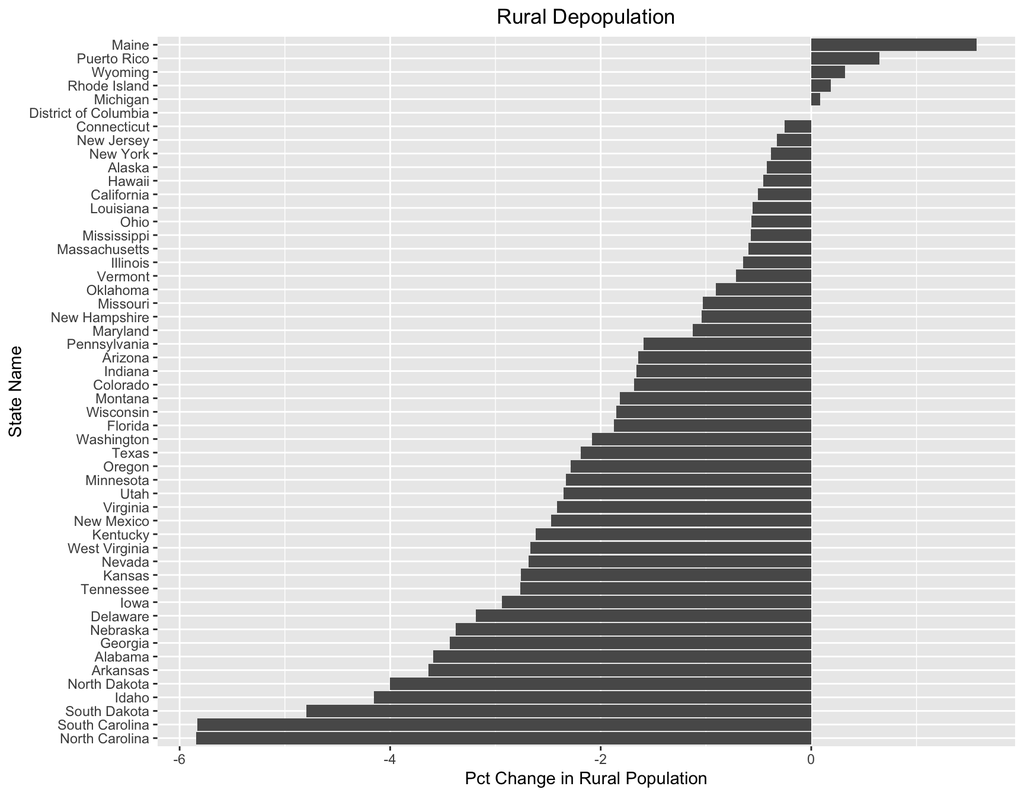

```r
basegraph<-rural_change %>%
  ggplot(aes(x = reorder(NAME,rural_pct_change), y=rural_pct_change)) +
  geom_col()+
  coord_flip()

basegraph+labs(title="Rural Depopulation", x="State Name", y="Pct Change in Rural Population")+
  theme(plot.title=element_text(hjust=0.5))
```

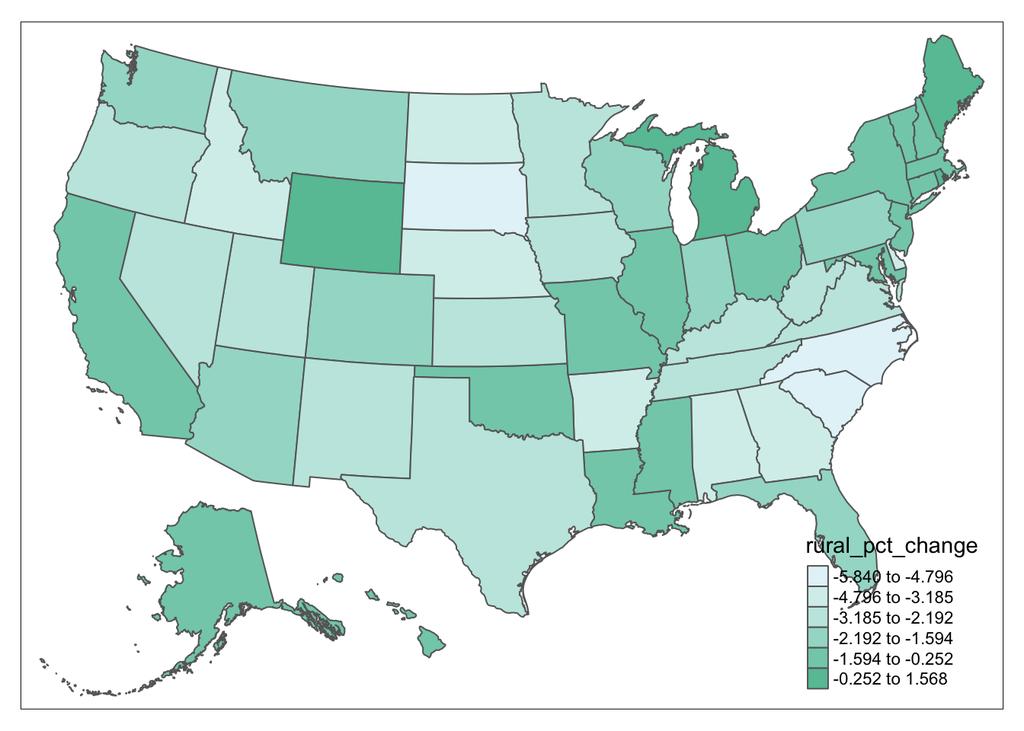

```r
rural_depop_tomap<-full_join(state_population_2010,rural_change,by="NAME")

foundational_map<-tm_shape(rural_depop_tomap)+
  tm_polygons(col="rural_pct_change", n=6,style="jenks",palette="BuGn", midpoint=TRUE)

foundational_map
```

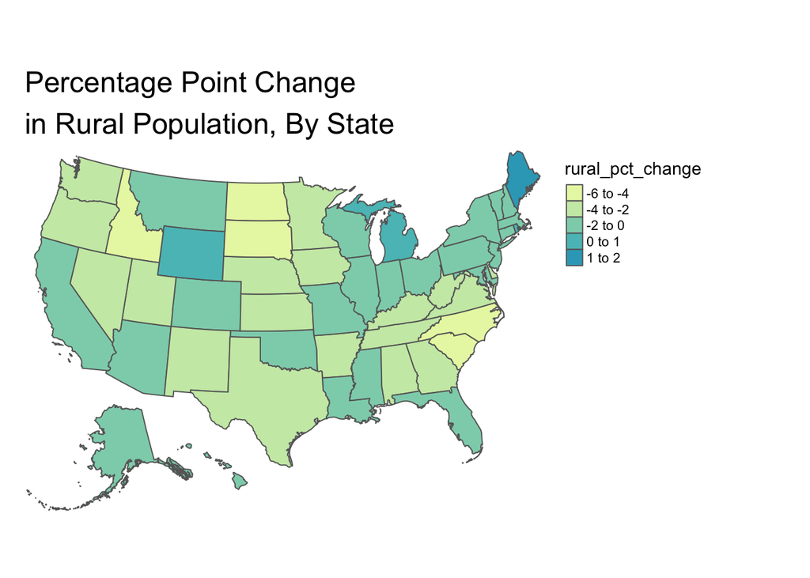

```r
##custom breaks and title
revised_map<-tm_shape(rural_depop_tomap)+
  tm_polygons(col="rural_pct_change", breaks=c(-6,-4,-2, 0, 1, 2),palette="YlGnBu", midpoint=TRUE)+
  tm_layout(frame=FALSE, main.title="Percentage Point Change\nin Rural Population, By State",
              main.title.position="left", legend.outside=TRUE)

revised_map
```

## Student Visualization Practice

### Option 1 Code

```r
median_age_CO<- get_decennial(geography = "county",
                              state="CO",
                              variables = "P013001",
                              year = 2010,
                              geometry = TRUE) %>%
                rename(median_age=value) %>%
                relocate(NAME)
```

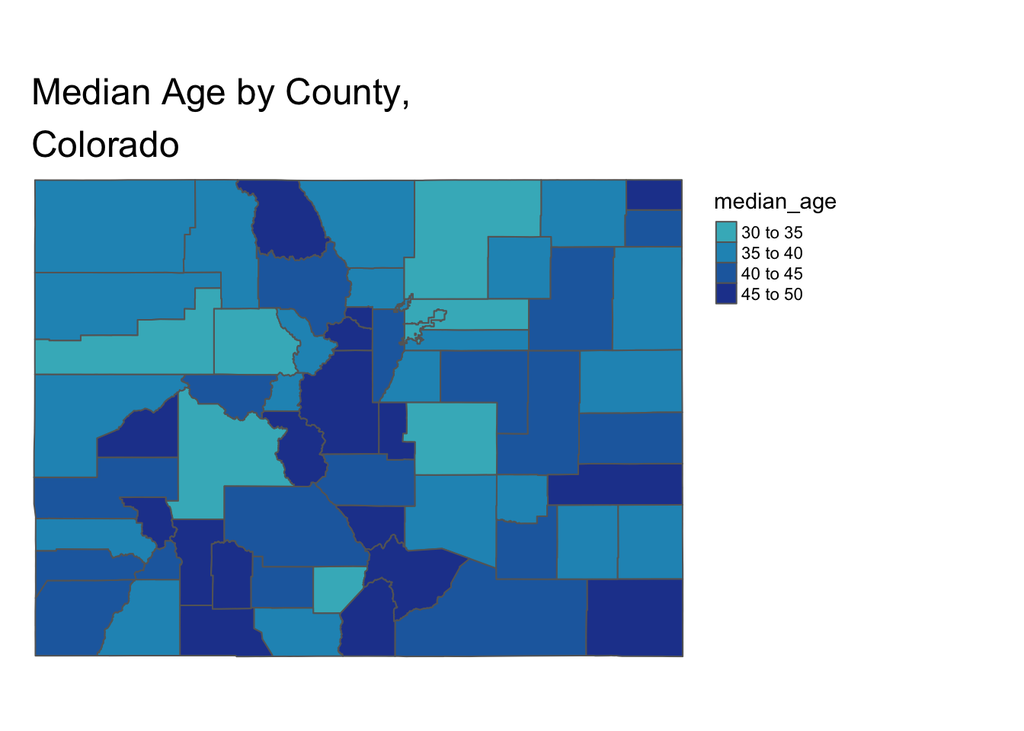

```r
median_age_CO_map<-tm_shape(median_age_CO)+
                   tm_polygons(col="median_age",breaks=c(30,35,40,45,50),palette="YlGnBu", midpoint=TRUE)+
                   tm_layout(frame=FALSE, main.title="Median Age by County,\nColorado",
                   main.title.position="left", legend.outside=TRUE)

median_age_CO_map
```

Making a Web Map

```r
tmap_mode("view")
median_age_CO_map
```

[interactive chart not shown]

### Option 2 Code

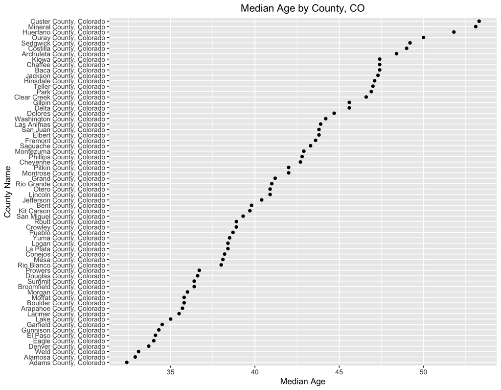

```r
median_age_CO_visualization<-
  median_age_CO %>%
  ggplot(aes(x = median_age, y = reorder(NAME, median_age))) +
  geom_point()+
  labs(title="Median Age by County, CO", x="Median Age", y="County Name")+
  theme(plot.title=element_text(hjust=0.5))

median_age_CO_visualization
```

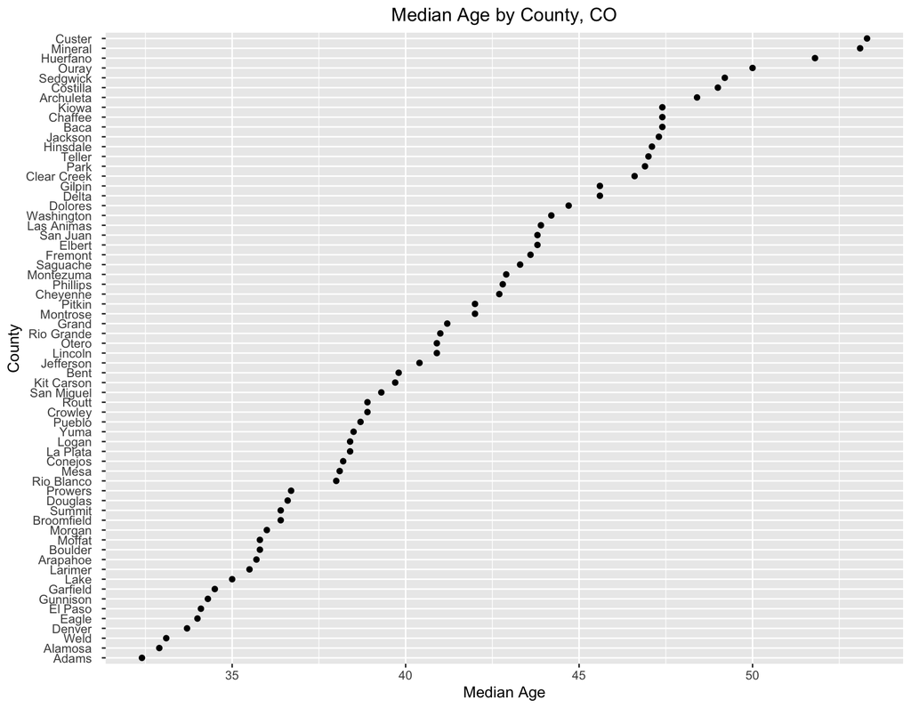

```r
median_age_CO_cleaned<-median_age_CO %>%
                       mutate(County_Name=str_remove_all(NAME,"Colorado|,|County"))

median_age_CO_cleaned_visualization<-
  median_age_CO_cleaned %>%
  ggplot(aes(x = median_age, y = reorder(County_Name, median_age))) +
  geom_point()+
  labs(title="Median Age by County, CO", x="Median Age", y="County")+
  theme(plot.title=element_text(hjust=0.5))

median_age_CO_cleaned_visualization
```

## American Community Survey

### Calling ACS Data

To inspect the variable list for the ACS, use the “load variables” function. Let’s say we want to work with the 5-year ACS ending in 2019:

```r
ACS_5_2019<-load_variables(2019,"acs5")
View(ACS_5_2019)
```

| name | label | concept |
| --- | --- | --- |
| B01001_001 | Estimate!!Total: | SEX BY AGE |
| B01001_002 | Estimate!!Total:!!Male: | SEX BY AGE |
| B01001_003 | Estimate!!Total:!!Male:!!Under 5 years | SEX BY AGE |
| B01001_004 | Estimate!!Total:!!Male:!!5 to 9 years | SEX BY AGE |
| B01001_005 | Estimate!!Total:!!Male:!!10 to 14 years | SEX BY AGE |
| B01001_006 | Estimate!!Total:!!Male:!!15 to 17 years | SEX BY AGE |

Let’s issue a call to the API and generate a table that gives us the median-income of the United States by county. We may want to eventually have the option of mapping this data, so we’ll set the geometry parameter equal to TRUE. Note that when using the “get_acs” function call, the default setting will return data from the 5-year ACS that terminates in the specified year (i.e. if the year parameter is set to 2019, the function will return the 2015-2019 ACS). If we want to call the 1 year or 3 year ACS, the “survey” argument of the “get_acs” function could be set to “acs1” or “acs3”, depending on which survey we are interested in calling.

```r
median_income<-get_acs(geography="county",
                       variables="B19013_001",
                       year=2019,
                       geometry=TRUE,
                       shift_geo=TRUE) %>%
              rename(median_income=estimate) %>%
              arrange(desc(median_income))

View(median_income)
```

| GEOID | NAME | variable | median_income | moe | geometry |
| --- | --- | --- | --- | --- | --- |
| 51107 | Loudoun County, Virginia | B19013_001 | 142299 | 2089 | MULTIPOLYGON (((1906352 -41… |
| 51610 | Falls Church city, Virginia | B19013_001 | 127610 | 16144 | MULTIPOLYGON (((1949973 -40… |
| 51059 | Fairfax County, Virginia | B19013_001 | 124831 | 1281 | MULTIPOLYGON (((1956587 -41… |
| 06085 | Santa Clara County, California | B19013_001 | 124055 | 1117 | MULTIPOLYGON (((-1902539 -6… |
| 06081 | San Mateo County, California | B19013_001 | 122641 | 1680 | MULTIPOLYGON (((-1952774 -6… |
| 35028 | Los Alamos County, New Mexico | B19013_001 | 121324 | 4613 | MULTIPOLYGON (((-565023.3 -… |

Let’s say that we want to generate a table that contains the highest median-income county for each state. To do so, we will use dplyr’s “group_by” and “slice” functions, after separating out the “Name” field in the existing table (which is in the form “County Name, State”) into separate “County” and “State” fields:

```r
highest_income_counties<-median_income %>%
                         separate(NAME,c("County","State"),sep=",") %>%
                         group_by(State) %>%
                         arrange(desc(median_income)) %>%
                         slice(1)

View(highest_income_counties)
```

```r
kable(highest_income_counties)
```

| GEOID | County | State | variable | median_income | moe | geometry |
| --- | --- | --- | --- | --- | --- | --- |
| 01117 | Shelby County | Alabama | B19013_001 | 77799 | 2248 | MULTIPOLYGON (((1207383 -12… |
| 02110 | Juneau City and Borough | Alaska | B19013_001 | 88390 | 4059 | MULTIPOLYGON (((-780061.4 -… |
| 04013 | Maricopa County | Arizona | B19013_001 | 64468 | 326 | MULTIPOLYGON (((-1075618 -1… |
| 05007 | Benton County | Arkansas | B19013_001 | 66362 | 1292 | MULTIPOLYGON (((490499.7 -9… |
| 06085 | Santa Clara County | California | B19013_001 | 124055 | 1117 | MULTIPOLYGON (((-1902539 -6… |
| 08035 | Douglas County | Colorado | B19013_001 | 119730 | 1710 | MULTIPOLYGON (((-432929.3 -… |
| 09001 | Fairfield County | Connecticut | B19013_001 | 95645 | 1039 | MULTIPOLYGON (((2153259 -17… |
| 10003 | New Castle County | Delaware | B19013_001 | 73892 | 1210 | MULTIPOLYGON (((2058738 -29… |
| 11001 | District of Columbia | District of Columbia | B19013_001 | 86420 | 1008 | MULTIPOLYGON (((1960720 -41… |
| 12109 | St. Johns County | Florida | B19013_001 | 82252 | 2741 | MULTIPOLYGON (((1768025 -14… |
| 13117 | Forsyth County | Georgia | B19013_001 | 107218 | 2004 | MULTIPOLYGON (((1441485 -10… |
| 15003 | Honolulu County | Hawaii | B19013_001 | 85857 | 907 | MULTIPOLYGON (((-481727.5 -… |
| 16081 | Teton County | Idaho | B19013_001 | 74216 | 3576 | MULTIPOLYGON (((-880601 -53… |
| 17093 | Kendall County | Illinois | B19013_001 | 96563 | 4721 | MULTIPOLYGON (((970466.8 -2… |
| 18057 | Hamilton County | Indiana | B19013_001 | 98173 | 2249 | MULTIPOLYGON (((1173473 -46… |
| 19049 | Dallas County | Iowa | B19013_001 | 88479 | 3234 | MULTIPOLYGON (((473355.5 -3… |
| 20091 | Johnson County | Kansas | B19013_001 | 89087 | 998 | MULTIPOLYGON (((467219 -668… |
| 21185 | Oldham County | Kentucky | B19013_001 | 99128 | 3974 | MULTIPOLYGON (((1262586 -63… |
| 22005 | Ascension Parish | Louisiana | B19013_001 | 80527 | 3017 | MULTIPOLYGON (((861410.4 -1… |
| 23005 | Cumberland County | Maine | B19013_001 | 73072 | 1427 | MULTIPOLYGON (((2332898 298… |
| 24027 | Howard County | Maryland | B19013_001 | 121160 | 2169 | MULTIPOLYGON (((1938398 -36… |
| 25019 | Nantucket County | Massachusetts | B19013_001 | 107717 | 5735 | MULTIPOLYGON (((2431244 400… |
| 26093 | Livingston County | Michigan | B19013_001 | 84221 | 1674 | MULTIPOLYGON (((1320579 -11… |
| 27139 | Scott County | Minnesota | B19013_001 | 102152 | 3021 | MULTIPOLYGON (((525638.1 -1… |
| 28089 | Madison County | Mississippi | B19013_001 | 71824 | 2728 | MULTIPOLYGON (((961529.6 -1… |
| 29183 | St. Charles County | Missouri | B19013_001 | 84978 | 1195 | MULTIPOLYGON (((817474.5 -6… |
| 30043 | Jefferson County | Montana | B19013_001 | 69646 | 4258 | MULTIPOLYGON (((-899443.3 1… |
| 31153 | Sarpy County | Nebraska | B19013_001 | 82032 | 1552 | MULTIPOLYGON (((341452 -429… |
| 32015 | Lander County | Nevada | B19013_001 | 88030 | 21398 | MULTIPOLYGON (((-1450087 -3… |
| 33015 | Rockingham County | New Hampshire | B19013_001 | 93756 | 1893 | MULTIPOLYGON (((2305592 212… |
| 34027 | Morris County | New Jersey | B19013_001 | 115527 | 1813 | MULTIPOLYGON (((2080464 -13… |
| 35028 | Los Alamos County | New Mexico | B19013_001 | 121324 | 4613 | MULTIPOLYGON (((-565023.3 -… |
| 36059 | Nassau County | New York | B19013_001 | 116100 | 1093 | MULTIPOLYGON (((2171497 -13… |
| 37183 | Wake County | North Carolina | B19013_001 | 80591 | 822 | MULTIPOLYGON (((1940120 -76… |
| 38105 | Williams County | North Dakota | B19013_001 | 87161 | 7443 | MULTIPOLYGON (((-298796 384… |
| 39041 | Delaware County | Ohio | B19013_001 | 106908 | 2786 | MULTIPOLYGON (((1451197 -37… |
| 40017 | Canadian County | Oklahoma | B19013_001 | 72056 | 1690 | MULTIPOLYGON (((211597.9 -1… |
| 41067 | Washington County | Oregon | B19013_001 | 82215 | 997 | MULTIPOLYGON (((-1743904 30… |
| 42029 | Chester County | Pennsylvania | B19013_001 | 100214 | 1232 | MULTIPOLYGON (((2060174 -23… |
| 44009 | Washington County | Rhode Island | B19013_001 | 85531 | 2042 | MULTIPOLYGON (((2319619 -14… |
| 45013 | Beaufort County | South Carolina | B19013_001 | 68377 | 1987 | MULTIPOLYGON (((1785885 -11… |
| 46083 | Lincoln County | South Dakota | B19013_001 | 82473 | 2951 | MULTIPOLYGON (((276504.4 -1… |
| 47187 | Williamson County | Tennessee | B19013_001 | 112962 | 2976 | MULTIPOLYGON (((1150429 -92… |
| 48397 | Rockwall County | Texas | B19013_001 | 100920 | 4011 | MULTIPOLYGON (((327048.3 -1… |
| 49043 | Summit County | Utah | B19013_001 | 102958 | 5613 | MULTIPOLYGON (((-920528.2 -… |
| 50007 | Chittenden County | Vermont | B19013_001 | 73647 | 2249 | MULTIPOLYGON (((2092685 314… |
| 51107 | Loudoun County | Virginia | B19013_001 | 142299 | 2089 | MULTIPOLYGON (((1906352 -41… |
| 53033 | King County | Washington | B19013_001 | 94974 | 726 | MULTIPOLYGON (((-1661250 51… |
| 54037 | Jefferson County | West Virginia | B19013_001 | 80430 | 3750 | MULTIPOLYGON (((1878385 -35… |
| 55133 | Waukesha County | Wisconsin | B19013_001 | 87277 | 1110 | MULTIPOLYGON (((929187.5 -1… |
| 56039 | Teton County | Wyoming | B19013_001 | 84678 | 8230 | MULTIPOLYGON (((-879496.6 -… |

## Additional Work with Dplyr and Visualization

##county median age map?

## Appendix

```r
my_years<-c(2000,2010)
population_rural_2000_2010<-map(
  my_years,
  ~(get_decennial(geography = "state",
                 variables = c("P001001", "P002005"),
                 output="wide",
                 year =.)) %>%
      mutate(rural_pct=(P002005/P001001)*100) %>%
      arrange(NAME)
  )
```

```
## Using Census Summary File 1
```

```
## Using Census Summary File 1
```

```r
names(population_rural_2000_2010)<-my_years

joined_ds<-full_join(population_rural_2000_2010[["2000"]],population_rural_2000_2010[["2010"]],by="NAME") %>%
           mutate(pct_change=rural_pct.y-rural_pct.x) %>%
           select(NAME,pct_change)
joined_ds
```

```
## # A tibble: 52 x 2
##    NAME                 pct_change
##    <chr>                     <dbl>
##  1 Alabama                  -3.59
##  2 Alaska                   -0.421
##  3 Arizona                  -1.64
##  4 Arkansas                 -3.64
##  5 California               -0.509
##  6 Colorado                 -1.68
##  7 Connecticut              -0.252
##  8 Delaware                 -3.18
##  9 District of Columbia      0
## 10 Florida                  -1.88
## # … with 42 more rows
```